# Question

Early probability theory explored what happens when you roll multiple dice. They did not have computers to run large simulations. We do.

In table-top role-playing games, it is common to use [dice notation](https://en.wikipedia.org/wiki/Dice_notation). I simulated 1000 repetitions of rolling 11d6+5d20. In each repetition, I rolled 11 six-sided dice and 5 twenty-sided dice and added up all the numbers to get a value. To analyze the distribution of these values, you will find **percentiles** using [nearest rank method](https://en.wikipedia.org/wiki/Percentile#The_nearest-rank_method).

83, 98, 52, 65, 87, 110, 98, 79, 101, 95, 66, 92, 106, 86, 99, 66, 85, 98, 99, 90, 78, 84, 108, 78, 104, 84, 92, 97, 111, 80, 130, 87, 102, 78, 94, 94, 92, 114, 89, 89, 109, 65, 67, 92, 64, 89, 71, 98, 66, 99, 92, 97, 89, 104, 107, 114, 73, 89, 102, 82, 77, 107, 129, 86, 95, 101, 84, 109, 105, 88, 92, 86, 108, 115, 127, 85, 103, 85, 59, 105, 109, 101, 80, 93, 111, 90, 97, 84, 83, 83, 81, 104, 89, 82, 73, 94, 83, 93, 82, 95, 75, 97, 76, 83, 84, 108, 78, 105, 115, 94, 107, 90, 85, 93, 103, 103, 125, 106, 87, 81, 97, 85, 112, 95, 118, 105, 107, 105, 111, 75, 91, 115, 109, 90, 90, 84, 129, 95, 114, 94, 88, 96, 69, 87, 71, 107, 95, 100, 91, 89, 87, 67, 103, 100, 77, 106, 92, 74, 97, 89, 93, 112, 67, 87, 102, 69, 105, 87, 108, 93, 101, 78, 71, 82, 85, 96, 102, 123, 69, 75, 102, 86, 93, 112, 98, 119, 77, 88, 87, 111, 85, 109, 94, 87, 87, 110, 107, 62, 95, 91, 72, 81, 88, 89, 113, 70, 84, 82, 76, 87, 118, 69, 118, 85, 84, 108, 60, 94, 91, 91, 101, 82, 89, 107, 113, 77, 84, 71, 83, 105, 89, 78, 77, 106, 91, 62, 102, 87, 99, 103, 88, 90, 106, 110, 108, 81, 82, 100, 115, 127, 100, 103, 113, 87, 93, 69, 97, 94, 87, 95, 95, 89, 71, 71, 84, 99, 67, 94, 92, 80, 90, 94, 71, 86, 102, 81, 77, 99, 81, 122, 114, 69, 80, 103, 83, 83, 94, 98, 79, 86, 89, 85, 98, 97, 108, 66, 78, 100, 116, 95, 90, 103, 107, 107, 74, 84, 103, 85, 86, 110, 99, 91, 80, 103, 111, 104, 87, 94, 95, 88, 90, 101, 81, 113, 69, 89, 95, 88, 64, 72, 109, 107, 76, 79, 93, 105, 61, 106, 73, 94, 106, 87, 77, 113, 94, 99, 84, 83, 96, 95, 99, 101, 113, 91, 106, 83, 82, 104, 109, 85, 112, 109, 99, 100, 90, 95, 73, 89, 65, 97, 83, 80, 49, 77, 67, 78, 81, 82, 90, 101, 100, 111, 110, 91, 82, 117, 85, 74, 96, 91, 122, 58, 61, 77, 95, 102, 118, 100, 108, 78, 79, 98, 111, 125, 87, 91, 80, 79, 89, 81, 84, 89, 86, 73, 106, 85, 90, 74, 115, 86, 83, 65, 116, 120, 92, 89, 87, 91, 95, 108, 65, 103, 92, 87, 112, 75, 123, 91, 81, 88, 81, 102, 114, 111, 105, 90, 81, 100, 84, 92, 102, 88, 100, 111, 89, 94, 96, 86, 110, 85, 79, 105, 119, 90, 110, 79, 84, 107, 82, 64, 105, 100, 101, 84, 93, 92, 88, 89, 80, 93, 95, 102, 98, 86, 94, 99, 95, 88, 98, 119, 96, 63, 97, 83, 101, 77, 69, 83, 93, 103, 88, 100, 100, 124, 97, 96, 67, 88, 82, 98, 93, 95, 90, 58, 78, 107, 62, 115, 93, 117, 86, 76, 91, 117, 103, 99, 100, 76, 75, 97, 84, 116, 77, 82, 124, 91, 83, 82, 104, 110, 93, 72, 83, 92, 94, 74, 109, 94, 75, 104, 117, 97, 76, 115, 95, 104, 87, 119, 109, 100, 93, 109, 82, 91, 78, 93, 103, 89, 91, 82, 86, 73, 89, 99, 95, 90, 88, 72, 106, 83, 80, 77, 90, 91, 78, 98, 107, 101, 85, 108, 65, 83, 98, 98, 89, 83, 82, 82, 84, 102, 97, 99, 76, 90, 100, 95, 97, 106, 88, 72, 91, 101, 71, 83, 89, 99, 92, 77, 112, 79, 95, 102, 63, 103, 74, 92, 96, 98, 101, 94, 68, 63, 108, 78, 98, 90, 100, 98, 91, 81, 108, 108, 81, 83, 91, 72, 94, 102, 98, 80, 88, 77, 65, 79, 84, 93, 105, 106, 88, 73, 93, 92, 80, 113, 96, 101, 91, 78, 84, 92, 94, 108, 74, 97, 58, 75, 91, 85, 89, 97, 111, 80, 86, 97, 97, 86, 79, 96, 94, 71, 125, 93, 102, 54, 67, 94, 79, 96, 93, 95, 86, 76, 85, 139, 92, 87, 113, 118, 91, 103, 101, 98, 87, 85, 77, 88, 97, 80, 77, 93, 77, 84, 82, 65, 83, 75, 58, 119, 115, 86, 89, 66, 59, 90, 78, 78, 97, 86, 101, 104, 110, 99, 112, 94, 109, 76, 116, 88, 80, 99, 93, 109, 78, 103, 118, 71, 97, 106, 87, 58, 87, 86, 73, 78, 82, 86, 84, 91, 73, 92, 97, 97, 71, 82, 79, 97, 107, 90, 79, 70, 108, 69, 85, 85, 86, 95, 95, 106, 121, 109, 77, 62, 126, 81, 86, 83, 113, 93, 64, 96, 111, 91, 116, 88, 98, 80, 82, 86, 67, 111, 91, 85, 99, 91, 75, 90, 94, 85, 89, 93, 69, 65, 94, 110, 119, 125, 98, 83, 94, 88, 76, 107, 75, 69, 85, 95, 73, 110, 71, 86, 86, 98, 95, 96, 88, 99, 79, 94, 75, 102, 85, 77, 67, 79, 106, 90, 90, 87, 79, 84, 109, 107, 105, 75, 67, 84, 61, 125, 91, 84, 108, 98, 106, 82, 98, 101, 99, 100, 93, 80, 81, 100, 116, 101, 77, 83, 80, 81, 88, 80, 111, 79, 98, 100, 92, 92, 86, 71, 89, 78, 88, 79, 115, 117, 103, 63, 134, 85, 96, 100, 78, 86, 88, 93, 93, 88, 73, 83, 84, 97, 92, 80, 93, 88, 84, 98, 73, 85, 98, 112, 91, 79, 97, 101, 103, 87, 72, 87, 68, 81, 83, 89, 84, 109, 80, 52, 83, 88, 82, 85, 72, 106, 101, 75, 102, 106, 100, 89, 90, 88, 68, 115, 95, 64, 86, 65, 72, 95, 95, 103, 73, 110, 67, 104, 90, 112, 66, 104, 110, 97, 71, 93, 106, 87, 89, 113, 92, 94, 77, 96, 106, 106, 76, 77, 110, 72, 101, 75, 83, 120

You might find it helpful to use a [data wrangling tool](https://chadworley.github.io/a2/tools/data_wrangler.html) before pasting into a [spreadsheet](https://sheets.new). But you can also paste, click the dropdown menu, select `split text to columns`, select all, cut, and paste special (transpose).

Once in the spreadsheet, you’ll want to sort the data.

### Find the following percentiles:

- The 2.5th percentile = ##ANSWER1##
- The 16th percentile = ##ANSWER2##
- The 50th percentile = ##ANSWER3##
- The 84th percentile = ##ANSWER4##
- The 97.5th percentile = ##ANSWER5##

## Answerlist

- 60
- 61
- 62
- 63
- 64
- 75
- 76
- 77
- 78
- 79
- 90
- 91
- 92
- 93
- 94
- 104
- 105
- 106
- 107
- 108
- 119
- 120
- 121
- 122
- 123

# Solution

You can see answers as the color changes in the sorted list below.

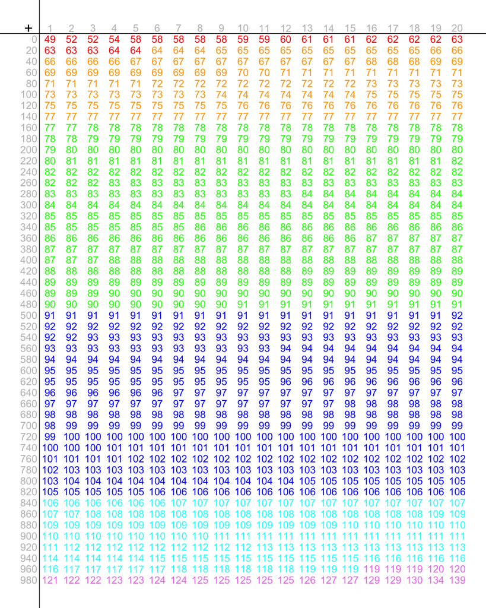

I’ve produced a dot plot that helps visualize these percentiles.

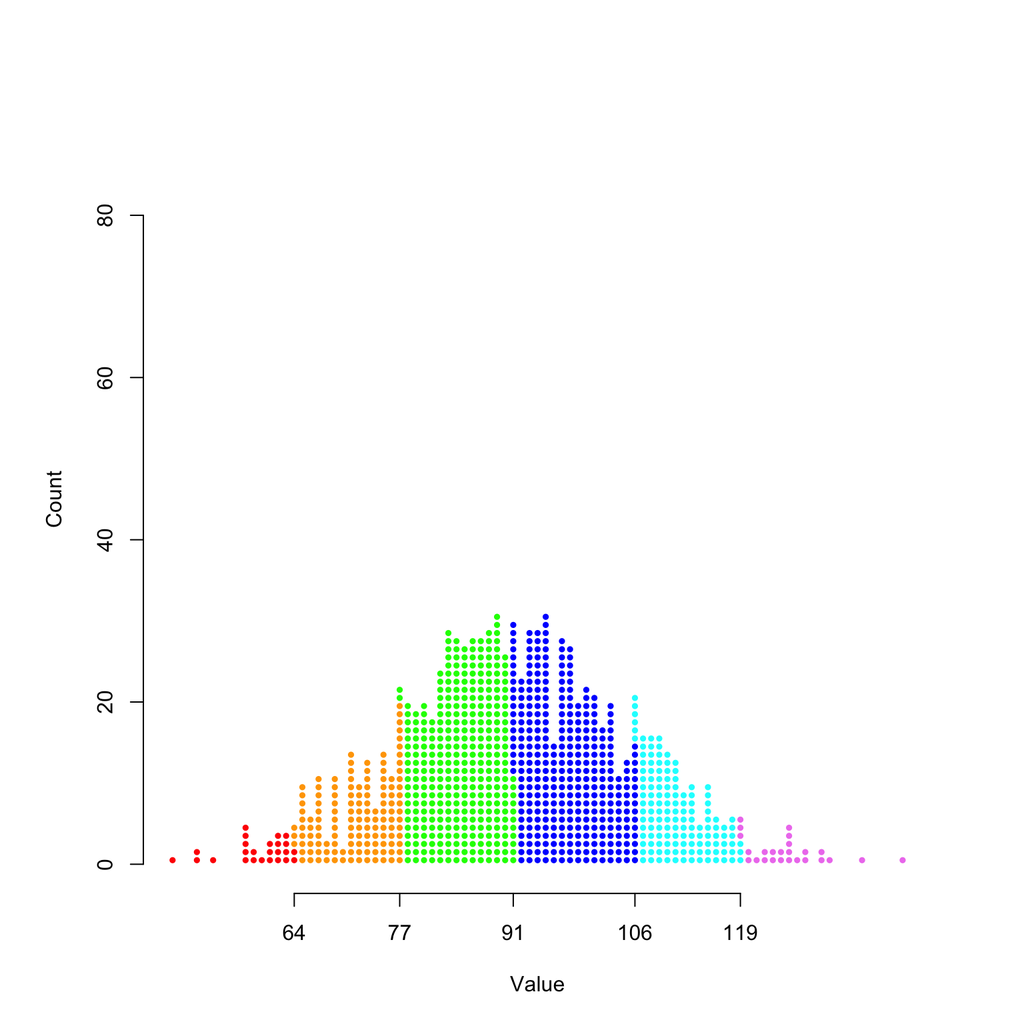

You might notice the five answers are spaced evenly-ish.

$$77-64=13$$
$$91-77=14$$
$$106-91=15$$
$$119-106=13$$

This is not a coincidence. Because each repetition of the simulation involves adding a bunch of independent random variables, we expect the output values to be [normally distributed](https://en.wikipedia.org/wiki/Normal_distribution).

If you’ve studied a lot of probability, you might know about standard deviation. If you look up [discrete uniform distribution](https://en.wikipedia.org/wiki/Discrete_uniform_distribution), you can find the formula for the standard deviation for a 6-sided die or a 20-sided die.

$$\mathrm{SD(1d6)} =
\sqrt{\frac{6^2-1}{12}} \approx 1.708$$
$$\mathrm{SD(1d20)} = \sqrt{\frac{20^2-1}{12}}
\approx 5.766$$

If you’ve REALLY studied probability, you might know one of the [most important reasons](https://en.wikipedia.org/wiki/Algebra_of_random_variables#Variance_algebra_for_random_variables) we use standard deviation: *if random variables X and Y are independent, then $\mathrm{SD(X+Y)=\sqrt{SD(X)^2+SD(Y)^2}}$*. This implies the following:

$$\mathrm{SD(11d6+5d20)} =
\sqrt{11\cdot1.708^2+5\cdot5.766^2} \approx 14.1$$

To learn more, read about the [central limit theorem](https://en.wikipedia.org/wiki/Central_limit_theorem) and the [68-95-99.7 rule](https://en.wikipedia.org/wiki/68%E2%80%9395%E2%80%9399.7_rule).

# Meta-information

extype: cloze exclozetype: schoice|schoice|schoice|schoice|schoice exsolution: 00001|00100|01000|00100|10000 exname: get_percentiles